# MY459: Assignment 1Solutions

Liu Hongtao

### Overview

The purpose of this assignment is to familiarize yourself with R, RMarkdown, and `quanteda`.

As with the rest of assignments throughout the term, the goal is to write R code in the chunks within this RMarkdown file that will accomplish the tasks detailed below. Where questions are asked, include your answer in the after the question.

Start by loading the `quanteda` package.

```r
library("quanteda")
## Package version: 1.3.14
## Parallel computing: 2 of 4 threads used.
## See https://quanteda.io for tutorials and examples.
##
## Attaching package: 'quanteda'
## The following object is masked from 'package:utils':
##
##     View
```

You will use the corpus of inaugural addresses by U.S. presidents `data_corpus_inaugural` for this part of the exercise. These data are available as soon as you load `quanteda` and are lazily-loaded once you access them.

Write code to inspect which inaugural address was the longest. Have a look at `texts()` to extract character vectors from the quanteda corpus object.

```r
which.max(nchar(texts(data_corpus_inaugural)))
## 1841-Harrison
##            14
```

### Question 1 (3 points)

Explain how this answer works. *texts()extract the text vectors from the quanteda corpus object, and then the nchar() can calculate the number of chracters in each address text. In the end the which.max will return which one has the biggest number of chracters* How could you do this using a **quanteda** function? *I can use the ntoken function from quanteda to do this (Codes are below)*

```r
which.max(ntoken(texts(data_corpus_inaugural)))
## 1841-Harrison
##            14
```

### Question 2 (3 points)

Which president gave the longest speech and in what year was that?

```r
tokenInfo <- summary(data_corpus_inaugural)
tokenInfo[which.max(tokenInfo$Tokens), ]
```

```
##             Text Types Tokens Sentences Year President     FirstName
## 14 1841-Harrison  1896   9144       210 1841  Harrison William Henry
```

*Harrison gave the longest speech in 1841* ### Question 3 (4 points)

Generate a document-feature matrix from this corpus and call it `sotu_dfm`. Make sure that the text is put into **lowercase** and words are **stemmed** as preprocessing steps.

```r
# fill in the line below
sotu_dfm <- dfm(data_corpus_inaugural, tolower=TRUE, stem=TRUE, verbose=TRUE)
## Creating a dfm from a corpus input...
##    ... lowercasing
##    ... found 58 documents, 9,357 features
##    ... stemming features (English)
## , trimmed 3816 feature variants
##    ... created a 58 x 5,541 sparse dfm
##    ... complete.
## Elapsed time: 0.197 seconds.
```

Now, look at the 20 most common features in the document-feature matrix.

```r
# examine top 20 common features
topfeatures(sotu_dfm, 20)
```

```
##   the    of     ,   and     .    to    in     a   our    it  that    we
## 10082  7103  7026  5310  4945  4526  2785  2246  2203  1962  1792  1739
##    be    is   for    by  have which  with   not
##  1544  1462  1197  1083  1057  1006   958   957
```

What do most of those tokens have in common?  
*Most of them are stop words and punctuations* What step(s) might you take to focus on a more interesting set of word frequencies? Write code below to apply those steps, if you consider it necessary. *Remove stop words and punctuations when creating the `dfm` object*

```r
sotu_dfm <- dfm(data_corpus_inaugural, remove=c(stopwords("english")), tolower=TRUE, remove_punct = TRUE, stem=TRUE, verbose=TRUE)
## Creating a dfm from a corpus input...
##    ... lowercasing
##    ... found 58 documents, 9,341 features
##    ... removed 136 features
##    ... stemming features (English)
## , trimmed 3800 feature variants
##    ... created a 58 x 5,405 sparse dfm
##    ... complete.
## Elapsed time: 0.169 seconds.
topfeatures(sotu_dfm, 20)
```

```
##    nation    govern     peopl        us       can     state     great
##       675       657       623       478       471       450       373
##      upon     power      must   countri     world       may     shall
##       371       370       366       355       339       338       314
##     everi constitut      peac     right       law      time
##       298       286       283       276       271       267
```

*we can remove punctuation and stops words to do word frequencies*

### Question 4 (3 points)

Write code to figure out how many different types of punctuation and how many different types of stopwords were removed.

```r
ncol(dfm(data_corpus_inaugural, tolower=TRUE, stem=TRUE, verbose=TRUE)) - ncol(dfm(data_corpus_inaugural, remove=c(stopwords("english")), tolower=TRUE, stem=TRUE, verbose=TRUE))
## Creating a dfm from a corpus input...
##    ... lowercasing
##    ... found 58 documents, 9,357 features
##    ... stemming features (English)
## , trimmed 3816 feature variants
##    ... created a 58 x 5,541 sparse dfm
##    ... complete.
## Elapsed time: 0.202 seconds.
## Creating a dfm from a corpus input...
##    ... lowercasing
##    ... found 58 documents, 9,357 features
##    ... removed 136 features
##    ... stemming features (English)
## , trimmed 3800 feature variants
##    ... created a 58 x 5,421 sparse dfm
##    ... complete.
## Elapsed time: 0.184 seconds.
## [1] 120
ncol(dfm(data_corpus_inaugural, tolower=TRUE, stem=TRUE, verbose=TRUE)) - ncol(dfm(data_corpus_inaugural, remove_punct = TRUE, tolower=TRUE, stem=TRUE, verbose=TRUE))
## Creating a dfm from a corpus input...
##    ... lowercasing
##    ... found 58 documents, 9,357 features
##    ... stemming features (English)
## , trimmed 3816 feature variants
##    ... created a 58 x 5,541 sparse dfm
##    ... complete.
## Elapsed time: 0.166 seconds.
## Creating a dfm from a corpus input...
##    ... lowercasing
##    ... found 58 documents, 9,341 features
##    ... stemming features (English)
## , trimmed 3816 feature variants
##    ... created a 58 x 5,525 sparse dfm
##    ... complete.
## Elapsed time: 0.245 seconds.
## [1] 16
```

*120 different types of stopwords and 16 different types of punctuations are removed* ### Question 5 (3 points)

Plot a wordcloud of the dfm that has the stopwords, punctuation characters, and numbers removed, but without stemming. Plot this only for words with a minimum count of 10.

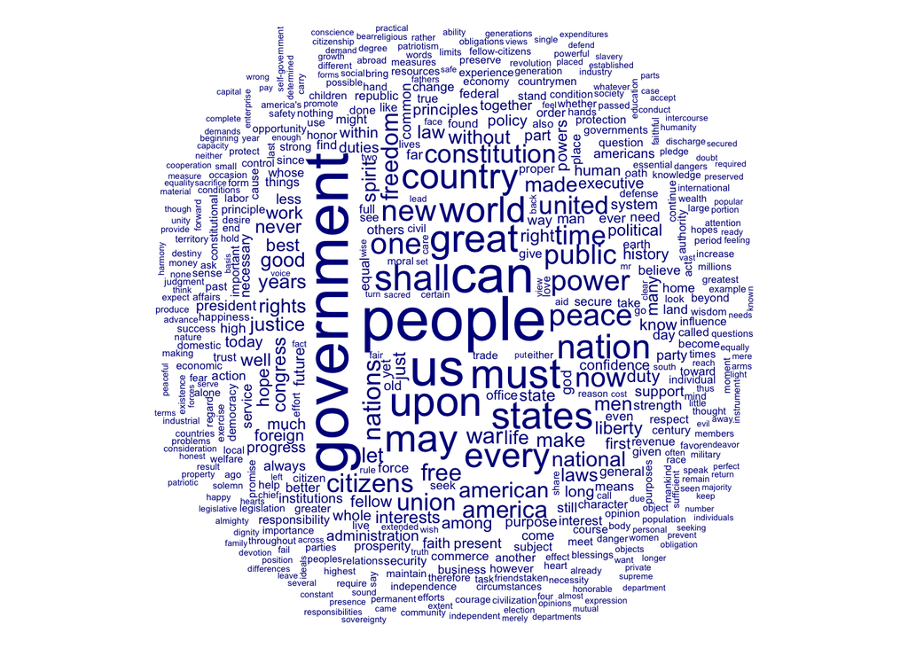

```r
textplot_wordcloud(dfm_trim(dfm(data_corpus_inaugural, remove=c(stopwords("english")), tolower=TRUE, remove_punct = TRUE, verbose=TRUE, stem=FALSE), min_docfreq=10), min_size = 0.4, max_size = 4)
## Creating a dfm from a corpus input...
##    ... lowercasing
##    ... found 58 documents, 9,341 features
##    ... removed 136 features
##    ... created a 58 x 9,205 sparse dfm
##    ... complete.
## Elapsed time: 0.126 seconds.
```

```r
?textplot_wordcloud
```

### Question 6 (2 points)

Search for the word “Christmas” from the `data_corpus_irishbudget2010` object. What is the context in which this term is being used?

Search for the word “Irish” and save the results of this keywords-in-context object to a new object called `irish_kwic`. Plot an “x-ray” plot for this kwic, in the code bloc below:

```r
kwic(data_corpus_irishbudget2010, "Christmas", window=10)
```

```
##
##       [2010_BUDGET_02_Richard_Bruton_FG, 699]
##         [2010_BUDGET_03_Joan_Burton_LAB, 419]
##         [2010_BUDGET_03_Joan_Burton_LAB, 428]
##        [2010_BUDGET_03_Joan_Burton_LAB, 1039]
##        [2010_BUDGET_03_Joan_Burton_LAB, 1701]
##        [2010_BUDGET_03_Joan_Burton_LAB, 1929]
##        [2010_BUDGET_03_Joan_Burton_LAB, 3508]
##        [2010_BUDGET_04_Arthur_Morgan_SF, 374]
##       [2010_BUDGET_04_Arthur_Morgan_SF, 3550]
##       [2010_BUDGET_04_Arthur_Morgan_SF, 3556]
##       [2010_BUDGET_04_Arthur_Morgan_SF, 3586]
##       [2010_BUDGET_04_Arthur_Morgan_SF, 6490]
##          [2010_BUDGET_06_Enda_Kenny_FG, 2873]
##     [2010_BUDGET_07_Kieran_ODonnell_FG, 1510]
##       [2010_BUDGET_08_Eamon_Gilmore_LAB, 608]
##       [2010_BUDGET_08_Eamon_Gilmore_LAB, 712]
##      [2010_BUDGET_08_Eamon_Gilmore_LAB, 1112]
##      [2010_BUDGET_13_Ciaran_Cuffe_Green, 992]
##  [2010_BUDGET_14_Caoimhghin_OCaolain_SF, 167]
##
##                  fingernails a chance to survive and to see out this |
##             heard Ryan Tubridy ask listeners to suggest titles for a |
##                a Christmas hit single. Fianna Fáil's hit single for |
##                    , many young men and women will say goodbye after |
##                  are doing a roaring trade in single golf clubs this |
##                lying? Is the Simon Community faking its message this |
##                    sees very few shopping bags. In previous years at |
##                                  , such as the€ 204 per week or the |
##             the effects of cuts made to social welfare payments this |
##              social welfare payments this Christmas. The loss of the |
##                  our shops on the high streets on Santa presents and |
##                       many people who lose their jobs, who face this |
##  The Government had an opportunity to implement the reduction before |
##           retailers no possibility to benefit from the change in the |
##                              will take a cut of€ 641, including the |
##               for children whose families are on social welfare, the |
##                    sparked a new wave of emigration. Once again this |
##                         will help us, I noted recently that over the |
##                          expecting him to say it will all be over by |
##
##  Christmas | in the hope of something better in the new year
##  Christmas | hit single. Fianna Fáil's hit single for Christmas will
##  Christmas | will be," I saw NAMA killing Santa Claus
##  Christmas | because they must take the decision to leave, as
##  Christmas | . With a possible election next year, one never
##  Christmas | ? Is the Society of St. Vincent de Paul
##  Christmas | time people were laden down with shopping bags. If
##  Christmas | bonus. Of course, that is not too complicated
##  Christmas | . The loss of the Christmas bonus, a double
##  Christmas | bonus, a double payment which affected 1.3 million people
##  Christmas | food. The Government's Scrooge measures will come back to
##  Christmas | in debt, in poverty and with the prospect of
##  Christmas | . I do not know whether Deputy Perry heard a
##  Christmas | period. We suggested that the lower rate of VAT
##  Christmas | payment. A couple on invalidity pension suffers a cut
##  Christmas | payment is gone. Earnest lectures on price statistics will
##  Christmas | , we will witness the scenes of heartbreak and loss
##  Christmas | recess work will be done in Leinster House to replace
##  Christmas | . If it is the last big push, we
```

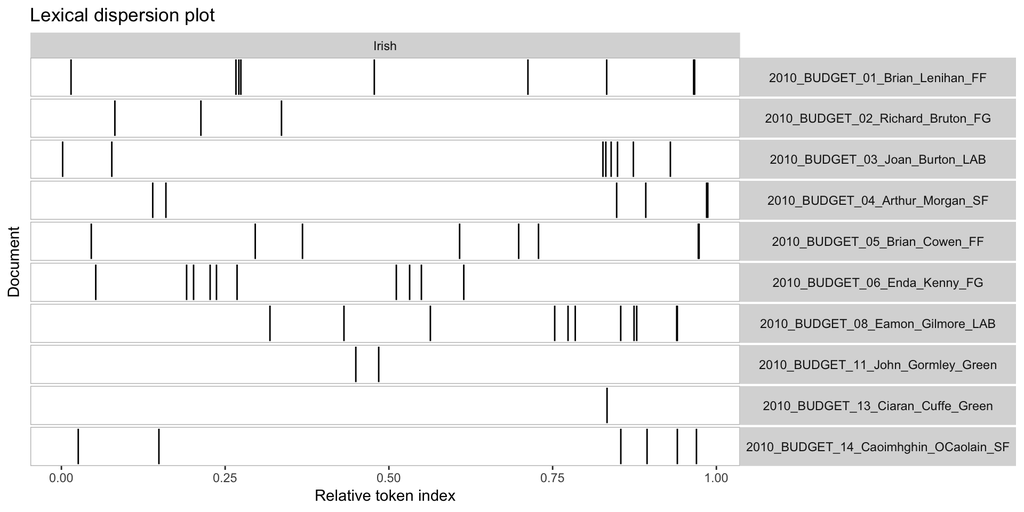

```r
irish_kwic <- kwic(data_corpus_irishbudget2010, "Irish", window=10)
textplot_xray(irish_kwic)
```

#### Question 7 (2 points)

Examine the context of words *related to* “disaster”. Hint: you can use the stem of the word along with setting the `regex` argument to `TRUE`. Execute a query using a pattern match that returns different variations of words based on “disaster” (such as disasters, disastrous, disastrously, etc.).

```r
kwic(data_corpus_irishbudget2010, pattern = "disast*", valuetype = "regex", stem = TRUE)
```

```
## Warning: Argument stem not used.
##
##       [2010_BUDGET_02_Richard_Bruton_FG, 3020]
##          [2010_BUDGET_03_Joan_Burton_LAB, 565]
##        [2010_BUDGET_04_Arthur_Morgan_SF, 1143]
##            [2010_BUDGET_06_Enda_Kenny_FG, 211]
##       [2010_BUDGET_08_Eamon_Gilmore_LAB, 1421]
##       [2010_BUDGET_08_Eamon_Gilmore_LAB, 1571]
##       [2010_BUDGET_08_Eamon_Gilmore_LAB, 3662]
##   [2010_BUDGET_14_Caoimhghin_OCaolain_SF, 835]
##  [2010_BUDGET_14_Caoimhghin_OCaolain_SF, 3683]
##  [2010_BUDGET_14_Caoimhghin_OCaolain_SF, 3848]
##
##      . Instead the Government has | disastrously |
##              VAT, the single most |  disastrous  |
##         which was caused by their |  disastrous  |
##     in our recovery from economic |   disaster   |
##         to deal with the economic |   disaster   |
##   commitment to dealing with this |   disaster   |
##  and international. Following the |  disastrous  |
##            however, thanks to the |  disastrous  |
##         is an alternative to this |  disastrous  |
##     are fighting back against the |  disastrous  |
##
##  mishandled those negotiations and it
##  action he took in the
##  policies and gross mismanagement.
##  . That was the view
##  that it created. The
##  even if it was of
##  handling of the banking crisis
##  policies and gross mismanagement of
##  budget. Sinn Féin presented
##  policies of this Fianna Fáil
```